# **Facial Emotion Detection**

## **Milestone 1**

## **Problem Definition**

**The context:** Why is this problem important to solve?

There are many emotional states which we can comprehend by looking at someone's facial expression. Like if someone is 'happy ‘or 'sad ‘or 'angry ‘or 'bored' or some other emotion.

Now, machine can also perform similar task with the help of Facial Emotion Detection or Emotional AI technology. It analyses human facial expressions and produces the emotional state as output. This output can be used as input to fix other problem areas or enhance the business or consumer experiences.

Let say, we record students' face every day when he/she enters the school, and we find that someone looks sad everyday then it indicates either something is wrong at home or something is bothering at school and student might need some emotional, psychological help. So, doing this manually is tedious task whereas if machine can provide us report periodically, then it would be easy to investigate the issue.

Human emotion is very complex. Here, we are trying to take help of Emotional AI to solve this complex equation.

**The objectives:** What is the intended goal?

Here our goal is to build a classification model using CNN to classify images as per the facial expression shown in the image. Our dataset contains four types of expressions: 'happy', 'sad', 'neutral' and 'surprise'. We want model to categorize our images as per the said labels.

**The key questions:** What are the key questions that need to be answered?

1. Is this classification model helpful?
2. How accurately it can classify?

**The problem formulation:** What are we trying to solve using data science?

We are trying to decode human emotions/feelings with the help of AI where input data is human face.

There is no single distinguishing facial movement for different expressions. Like, laughing loud with open mouth is happy expression whereas baby crying with open mouth is sad expression. When we smile, area around eyes get wrinkled but old people are having wrinkled skin.  
So, its combination of facial movements which describes one single expression.  
Hence, extracting all those features or facial movements which make one expression is a challenge here. Let see how accurately our model can predict the expression.

## **About the dataset**

The data set consists of 3 folders, i.e., 'test', 'train', and 'validation'. Each of these folders has four subfolders:

**‘happy’**: Images of people who have happy facial expressions.  
**‘sad’**: Images of people with sad or upset facial expressions.  
**‘surprise’**: Images of people who have shocked or surprised facial expressions.  
**‘neutral’**: Images of people showing no prominent emotion in their facial expression at all.

## **Important Notes**

- This notebook can be considered a guide to refer to while solving the problem. The evaluation will be as per the Rubric shared for each Milestone. Unlike previous courses, it does not follow the pattern of the graded questions in different sections. This notebook would give you a direction on what steps need to be taken to get a feasible solution to the problem. Please note that this is just one way of doing this. **There can be other 'creative' ways to solve the problem, and we encourage you to feel free and explore them as an 'optional' exercise**.
- In the notebook, there are markdown cells called Observations and Insights. It is a good practice to provide observations and extract insights from the outputs.
- The naming convention for different variables can vary. **Please consider the code provided in this notebook as a sample code.**
- All the outputs in the notebook are just for reference and can be different if you follow a different approach.
- There are sections called **Think About It** in the notebook that will help you get a better understanding of the reasoning behind a particular technique/step. Interested learners can take alternative approaches if they want to explore different techniques.

## **Mounting the Drive**

**NOTE:** Please use Google Colab from your browser for this notebook. **Google.colab is NOT a library that can be downloaded locally on your device.**

```python
# #convert to html file
  %%shell
  jupyter nbconvert --to html '/content/drive/MyDrive/Capstone_project/AnjuPandey_Facial_Emotion_Detection_Milestone+1.ipynb'
```

```
[NbConvertApp] Converting notebook /content/drive/MyDrive/Capstone_project/AnjuPandey_Facial_Emotion_Detection_Milestone+1.ipynb to html
[NbConvertApp] Writing 1325359 bytes to /content/drive/MyDrive/Capstone_project/AnjuPandey_Facial_Emotion_Detection_Milestone+1.html
```

```python
from google.colab import drive
drive.mount('/content/drive')
```

## **Importing the Libraries**

```python
import zipfile
import matplotlib.pyplot as plt
import numpy as np
import pandas as pd
import seaborn as sns
import os

# Importing Deep Learning Libraries

from tensorflow.keras.preprocessing.image import load_img, img_to_array
from tensorflow.keras.preprocessing.image import ImageDataGenerator
from tensorflow.keras.layers import Dense, Input, Dropout, GlobalAveragePooling2D, Flatten, Conv2D, BatchNormalization, Activation, MaxPooling2D, LeakyReLU
from tensorflow.keras.models import Model, Sequential
from tensorflow.keras.optimizers import Adam, SGD, RMSprop
```

### **Let us load the data**

**Note:**

- You must download the dataset from the link provided on Olympus and upload the same on your Google drive before executing the code in the next cell.
- In case of any error, please make sure that the path of the file is correct as the path may be different for you.

```python
# Storing the path of the data file from the Google drive
#path = '/content/drive/MyDrive/Capstone_project/Facial_emotion_images.zip'
path = '/content/Facial_emotion_images.zip'

# The data is provided as a zip file so we need to extract the files from the zip file
with zipfile.ZipFile(path, 'r') as zip_ref:
      zip_ref.extractall(path='/content/')#(path='/content/drive/MyDrive/Capstone_project/')
```

```python
picture_size = 48
folder_path = "/content/Facial_emotion_images/"
```

## **Visualizing our Classes**

Let's look at our classes.

**Write down your observation for each class. What do you think can be a unique feature of each emotion, that separates it from the remaining classes?**

### **Happy**

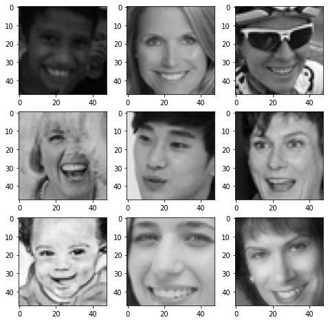

```python
expression = 'happy'

plt.figure(figsize= (8,8))
for i in range(1, 10, 1):
    plt.subplot(3, 3, i)

    img = load_img(folder_path + "train/" + expression + "/" +
                  os.listdir(folder_path + "train/" + expression)[i], target_size = (picture_size, picture_size))
    plt.imshow(img)

plt.show()
```

**Observations and Insights:__**  
Above plot shows the happy faces. To distinguish happy expression from other expressions, we need to focus on the lip, eye, and forehead areas. Commonly, happy expression involves lip corner rising diagonally, slightly squinched eyes -but forehead muscles are not stressed or wrinkled.

### **Sad**

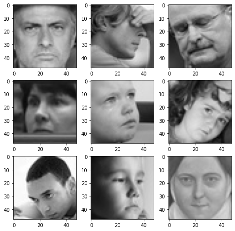

```python
# Write your code to visualize images from the class 'sad'.
expression = 'sad'

plt.figure(figsize= (8,8))
for i in range(1, 10, 1):
    plt.subplot(3, 3, i)

    img = load_img(folder_path + "train/" + expression + "/" +
                  os.listdir(folder_path + "train/" + expression)[i], target_size = (picture_size, picture_size))
    plt.imshow(img)

plt.show()
```

**Observations and Insights:__**  
Above plot shows the sad faces. Commonly, in sad expression, below facial movements are involved:

- Drooping eyelids
- Raised inner eyebrows
- Lip corner pulled down
- Tears

### **Neutral**

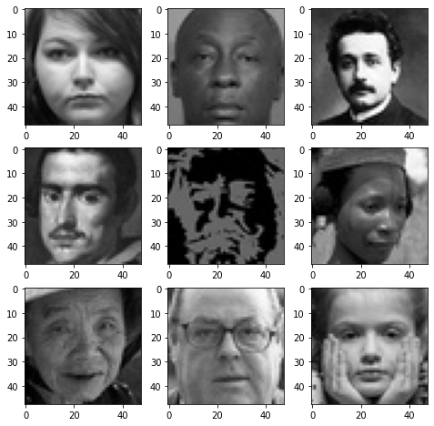

```python
# Write your code to visualize images from the class 'neutral'.
expression = 'neutral'

plt.figure(figsize= (8,8))
for i in range(1, 10, 1):
    plt.subplot(3, 3, i)

    img = load_img(folder_path + "train/" + expression + "/" +
                  os.listdir(folder_path + "train/" + expression)[i], target_size = (picture_size, picture_size))
    plt.imshow(img)

plt.show()
```

**Observations and Insights:__**

Above plot shows the neutral faces. Neutral face can be seen as blank expression, i.e. no facial movement is involved. We can describe this expression with below features:

- straight-lined mouths
- relaxed eyes (not wide opened or squinched)

### **Surprised**

[figure not shown]

```python
# Write your code to visualize images from the class 'surprise'.
expression = 'surprise'

plt.figure(figsize= (8,8))
for i in range(1, 10, 1):
    plt.subplot(3, 3, i)

    img = load_img(folder_path + "train/" + expression + "/" +
                  os.listdir(folder_path + "train/" + expression)[i], target_size = (picture_size, picture_size))
    plt.imshow(img)

plt.show()
```

**Observations and Insights:__**  
Above plot shows the surprised faces. We can describe this expression as below:

- Wide opened eyes
- Mouth/Jaw opened
- Raised eyebrows

## **Checking Distribution of Classes**

```python
# Getting count of images in each folder within our training path
num_happy = len(os.listdir(folder_path + "train/happy"))
num_sad = len(os.listdir(folder_path + "train/sad"))
num_neutral = len(os.listdir(folder_path + "train/neutral"))
num_surprise = len(os.listdir(folder_path + "train/surprise"))
print("Number of images in the class 'happy':   ", num_happy)
print("Number of images in the class 'sad':   ", num_sad)
print("Number of images in the class 'neutral':   ", num_neutral)
print("Number of images in the class 'surprise':   ", num_surprise)
```

```
Number of images in the class 'happy':    3976
Number of images in the class 'sad':    3982
Number of images in the class 'neutral':    3978
Number of images in the class 'surprise':    3173
```

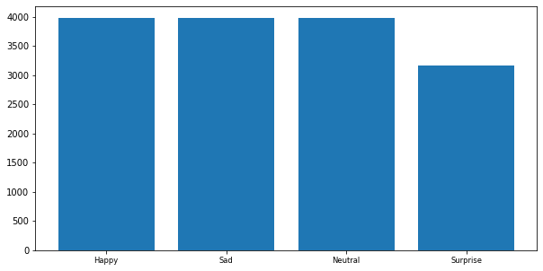

```python
# Code to plot histogram
plt.figure(figsize = (10, 5))

data = {'Happy': num_happy, 'Sad': num_sad, 'Neutral': num_neutral, 'Surprise' : num_surprise}

df = pd.Series(data)

plt.bar(range(len(df)), df.values, align = 'center')

plt.xticks(range(len(df)), df.index.values, size = 'small')

plt.show()
```

**Observations and Insights:__**  
There are four categories/labels: ‘happy’, ’sad’, ’neutral’ and ‘surprise.’ Number of images contained in each class for training data is as follows:

- Happy – 3976
- Sad – 3982
- Neutral – 3978
- Surprise – 3173

‘Surprise’ category is having approx. 21% of data while other categories are having approx. 26% of data. As the difference is not huge so we can say that data is distributed equally.

This bar plot is giving us good understanding of data distribution.

**Think About It:**

- Are the classes equally distributed? If not, do you think the imbalance is too high? Will it be a problem as we progress?
- Are there any Exploratory Data Analysis tasks that we can do here? Would they provide any meaningful insights?

```python
num_happy = len(os.listdir(folder_path + "train/happy"))
num_sad = len(os.listdir(folder_path + "train/sad"))
num_neutral = len(os.listdir(folder_path + "train/neutral"))
num_surprise = len(os.listdir(folder_path + "train/surprise"))

num_happy_v = len(os.listdir(folder_path + "validation/happy"))
num_sad_v = len(os.listdir(folder_path + "validation/sad"))
num_neutral_v = len(os.listdir(folder_path + "validation/neutral"))
num_surprise_v = len(os.listdir(folder_path + "validation/surprise"))

num_happy_t = len(os.listdir(folder_path + "test/happy"))
num_sad_t = len(os.listdir(folder_path + "test/sad"))
num_neutral_t = len(os.listdir(folder_path + "test/neutral"))
num_surprise_t = len(os.listdir(folder_path + "test/surprise"))

total_train=num_happy+num_sad+num_neutral+num_surprise
total_val=num_happy_v+num_sad_v+num_neutral_v+num_surprise_v
total_test=num_happy_t+num_sad_t+num_neutral_t+num_surprise_t
print('Total Training Data:',total_train)
print('Total Validation Data:',total_val)
print('Total Test Data:',total_test)
```

```
Total Training Data: 15109
Total Validation Data: 4977
Total Test Data: 128
```

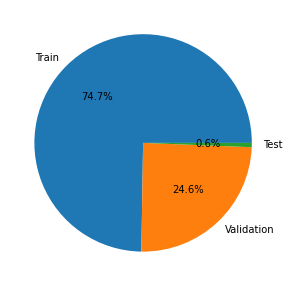

```python
# Code to plot histogram
plt.figure(figsize = (10, 5))

data = {'Train': total_train, 'Validation': total_val, 'Test': total_test}

df = pd.Series(data)
plt.pie(df.values,labels=df.index.values,autopct='%1.1f%%')


plt.show()
```

Above pie chart shows the percentage of data being used for training,validation and test.

## **Creating our Data Loaders**

In this section, we are creating data loaders that we will use as inputs to our Neural Network. A sample of the required code has been given with respect to the training data. Please create the data loaders for validation and test set accordingly.

**You have two options for the color_mode. You can set it to color_mode = 'rgb' or color_mode = 'grayscale'. You will need to try out both and see for yourself which one gives better performance.**

```python
batch_size  = 32
img_size = 48

datagen_train = ImageDataGenerator(horizontal_flip = True,
                                    brightness_range=(0.,2.),
                                    rescale=1./255,
                                    shear_range=0.3)

train_set = datagen_train.flow_from_directory(folder_path + "train",
                                              target_size = (img_size, img_size),
                                              color_mode = 'grayscale',# Provide your chosen color_mode here ,
                                              batch_size = batch_size,
                                              class_mode = 'categorical',
                                              shuffle = True)


datagen_validation = ImageDataGenerator(horizontal_flip = True,
                                    brightness_range=(0.,2.),
                                    rescale=1./255,
                                    shear_range=0.3)

validation_set= datagen_validation.flow_from_directory(folder_path + "validation",
                                              target_size = (img_size, img_size),
                                              color_mode ='grayscale', # Provide your chosen color_mode here ,
                                              batch_size = batch_size,
                                              class_mode = 'categorical',
                                              shuffle = True)


datagen_test = ImageDataGenerator(horizontal_flip = True,
                                    brightness_range=(0.,2.),
                                    rescale=1./255,
                                    shear_range=0.3)

test_set = datagen_test.flow_from_directory(folder_path + "test",
                                              target_size = (img_size, img_size),
                                              color_mode ='grayscale', # Provide your chosen color_mode here ,
                                              batch_size = batch_size,
                                              class_mode = 'categorical',
                                              shuffle = True)
```

```
Found 15109 images belonging to 4 classes.
Found 4977 images belonging to 4 classes.
Found 128 images belonging to 4 classes.
```

## **Model Building**

**Think About It:**

- Are Convolutional Neural Networks the right approach? Should we have gone with Artificial Neural Networks instead?
- What are the advantages of CNNs over ANNs and are they applicable here?

**ANN vs. CNN:**  
------------------------------------------------

If we have to solve image classification problem with ANN then below are the drawbacks:

First, we need to convert 2-dimensional image into a 1-dimensional vector. And this process creates huge number of parameters to be trained.

In images, pixels are arranged in certain way and that special arrangement is called Spatial features. When image is converted into 1-dimensional vector, ANN loses the spatial feature.

We do not need whole image or all the pixels of image for classification. ANN lacks the functionality of extracting only the relevant features and thus we get huge number of parameters which are not needed actually.

CNN uses filters(kernels). Convolution or filter is applied to input image and relevant features are extracted. It captures the spatial features in relation to other objects in the image. CNN’s ‘maxpooling’ layer reduces the image dimension but keeps the more prominent/ important features.

Hence, CNN will be better choice for image classification problem.

### **Creating the Base Neural Network**

Our Base Neural network will be a fairly simple model architecture.

- We want our Base Neural Network architecture to have 3 convolutional blocks.
- Each convolutional block must contain one Conv2D layer followed by a maxpooling layer and one Dropout layer. We can play around with the dropout ratio.
- Add first Conv2D layer with **64 filters** and a **kernel size of 2**. Use the 'same' padding and provide the **input_shape = (48, 48, 3) if you are using 'rgb' color mode in your dataloader or else input shape = (48, 48, 1) if you're using 'grayscale' colormode**. Use **'relu' activation**.
- Add MaxPooling2D layer with **pool size = 2**.
- Add a Dropout layer with a dropout ratio of 0.2.
- Add a second Conv2D layer with **32 filters** and a **kernel size of 2**. Use the **'same' padding** and **'relu' activation.**
- Follow this up with a similar Maxpooling2D layer like above and a Dropout layer with 0.2 Dropout ratio to complete your second Convolutional Block.
- Add a third Conv2D layer with **32 filters** and a **kernel size of 2**. Use the **'same' padding** and **'relu' activation.** Once again, follow it up with a Maxpooling2D layer and a Dropout layer to complete your third Convolutional block.
- After adding your convolutional blocks, add your Flatten layer.
- Add your first Dense layer with **512 neurons**. Use **'relu' activation function**.
- Add a Dropout layer with dropout ratio of 0.4.
- Add your final Dense Layer with 4 neurons and **'softmax' activation function**
- Print your model summary

```python
# Initializing a Sequential Model
model1 = Sequential()
# 1st
model1.add(Conv2D(64,(2,2),padding='same',input_shape=(48,48,1),activation='relu'))
model1.add(MaxPooling2D((2,2)))
model1.add(Dropout(0.2))
#2nd
model1.add(Conv2D(32,(2,2),padding='same',activation='relu'))
model1.add(MaxPooling2D((2,2)))
model1.add(Dropout(0.2))
#3rd
model1.add(Conv2D(32,(2,2),padding='same',activation='relu'))
model1.add(MaxPooling2D((2,2)))
model1.add(Dropout(0.2))
#Flatten
model1.add(Flatten())
#Dense
model1.add(Dense(512,activation='relu'))
model1.add(Dropout(0.4))
model1.add(Dense(4,activation='softmax'))
#model summary
model1.summary()
```

```
Model: "sequential"
_________________________________________________________________
 Layer (type)                Output Shape              Param #
=================================================================
 conv2d (Conv2D)             (None, 48, 48, 64)        320

 max_pooling2d (MaxPooling2D  (None, 24, 24, 64)       0
 )

 dropout (Dropout)           (None, 24, 24, 64)        0

 conv2d_1 (Conv2D)           (None, 24, 24, 32)        8224

 max_pooling2d_1 (MaxPooling  (None, 12, 12, 32)       0
 2D)

 dropout_1 (Dropout)         (None, 12, 12, 32)        0

 conv2d_2 (Conv2D)           (None, 12, 12, 32)        4128

 max_pooling2d_2 (MaxPooling  (None, 6, 6, 32)         0
 2D)

 dropout_2 (Dropout)         (None, 6, 6, 32)          0

 flatten (Flatten)           (None, 1152)              0

 dense (Dense)               (None, 512)               590336

 dropout_3 (Dropout)         (None, 512)               0

 dense_1 (Dense)             (None, 4)                 2052

=================================================================
Total params: 605,060
Trainable params: 605,060
Non-trainable params: 0
_________________________________________________________________
```

### **Compiling and Training the Model**

```python
from keras.callbacks import ModelCheckpoint, EarlyStopping, ReduceLROnPlateau

checkpoint = ModelCheckpoint("./model1.h5", monitor='val_acc', verbose=1, save_best_only=True, mode='max')

early_stopping = EarlyStopping(monitor = 'val_loss',
                          min_delta = 0,
                          patience = 3,
                          verbose = 1,
                          restore_best_weights = True
                          )

reduce_learningrate = ReduceLROnPlateau(monitor = 'val_loss',
                              factor = 0.2,
                              patience = 3,
                              verbose = 1,
                              min_delta = 0.0001)

callbacks_list = [early_stopping, checkpoint, reduce_learningrate]

epochs = 20
```

```python
# Write your code to compile your model1.
#Use categorical crossentropy as your loss function, Adam Optimizer with 0.001 learning rate,
#and set your metrics to 'accuracy'.
model1.compile(optimizer=Adam(learning_rate=.001),metrics=['accuracy'],loss='categorical_crossentropy')
```

```python
# Write your code to fit your model1. Use train_set as your training data and validation_set as your validation data. Train your model for 20 epochs.

history = model1.fit(train_set,epochs=20,verbose=1,validation_data = validation_set)
```

[output not shown]

### **Evaluating the Model on the Test Set**

```python
# Write your code to evaluate your model on test data.
model1.evaluate(test_set)
```

```
[0.8384631276130676, 0.6171875]
```

**Observations and Insights:__**

After 20 epochs, model's accuracy level was 62.48% for training data,64.72% for validation data and 61.72% for test data.

Certainly, this CNN architecture is not the preferred one as accuracy level is not very good.

### **Creating the second Convolutional Neural Network**

In the second Neural network, we will add a few more Convolutional blocks. We will also use Batch Normalization layers.

- This time, each Convolutional block will have 1 Conv2D layer, followed by a BatchNormalization, LeakuRelU, and a MaxPooling2D layer. We are not adding any Dropout layer this time.
- Add first Conv2D layer with **256 filters** and a **kernel size of 2**. Use the 'same' padding and provide the **input_shape = (48, 48, 3) if you are using 'rgb' color mode in your dataloader or else input shape = (48, 48, 1) if you're using 'grayscale' colormode**. Use **'relu' activation**.
- Add your BatchNormalization layer followed by a LeakyRelU layer with Leaky ReLU parameter of **0.1**
- Add MaxPooling2D layer with **pool size = 2**.
- Add a second Conv2D layer with **128 filters** and a **kernel size of 2**. Use the **'same' padding** and **'relu' activation.**
- Follow this up with a similar BatchNormalization, LeakyRelU, and Maxpooling2D layer like above to complete your second Convolutional Block.
- Add a third Conv2D layer with **64 filters** and a **kernel size of 2**. Use the **'same' padding** and **'relu' activation.** Once again, follow it up with a BatchNormalization, LeakyRelU, and Maxpooling2D layer to complete your third Convolutional block.
- Add a fourth block, with the Conv2D layer having **32 filters**.
- After adding your convolutional blocks, add your Flatten layer.
- Add your first Dense layer with **512 neurons**. Use **'relu' activation function**.
- Add the second Dense Layer with **128 neurons** and use **'relu' activation** function.
- Add your final Dense Layer with 4 neurons and **'softmax' activation function**
- Print your model summary

```python
# Creating sequential model
model2 = Sequential()
# 1st
model2.add(Conv2D(256,(2,2),padding='same',activation='relu',input_shape=(48,48,1)))
model2.add(BatchNormalization())
model2.add(LeakyReLU(alpha=0.1))
model2.add(MaxPooling2D((2,2)))
#2nd
model2.add(Conv2D(128,(2,2),padding='same',activation='relu'))
model2.add(BatchNormalization())
model2.add(LeakyReLU(alpha=0.1))
model2.add(MaxPooling2D((2,2)))
#3rd
model2.add(Conv2D(64,(2,2),padding='same',activation='relu'))
model2.add(BatchNormalization())
model2.add(LeakyReLU(alpha=0.1))
model2.add(MaxPooling2D((2,2)))
#4th
model2.add(Conv2D(32,(2,2)))
#Flatten
model2.add(Flatten())
model2.add(Dense(512,activation='relu'))
model2.add(Dense(128,activation='relu'))
model2.add(Dense(4,activation='softmax'))
#summary
model2.summary()
```

```
Model: "sequential_1"
_________________________________________________________________
 Layer (type)                Output Shape              Param #
=================================================================
 conv2d_3 (Conv2D)           (None, 48, 48, 256)       1280

 batch_normalization (BatchN  (None, 48, 48, 256)      1024
 ormalization)

 leaky_re_lu (LeakyReLU)     (None, 48, 48, 256)       0

 max_pooling2d_3 (MaxPooling  (None, 24, 24, 256)      0
 2D)

 conv2d_4 (Conv2D)           (None, 24, 24, 128)       131200

 batch_normalization_1 (Batc  (None, 24, 24, 128)      512
 hNormalization)

 leaky_re_lu_1 (LeakyReLU)   (None, 24, 24, 128)       0

 max_pooling2d_4 (MaxPooling  (None, 12, 12, 128)      0
 2D)

 conv2d_5 (Conv2D)           (None, 12, 12, 64)        32832

 batch_normalization_2 (Batc  (None, 12, 12, 64)       256
 hNormalization)

 leaky_re_lu_2 (LeakyReLU)   (None, 12, 12, 64)        0

 max_pooling2d_5 (MaxPooling  (None, 6, 6, 64)         0
 2D)

 conv2d_6 (Conv2D)           (None, 5, 5, 32)          8224

 flatten_1 (Flatten)         (None, 800)               0

 dense_2 (Dense)             (None, 512)               410112

 dense_3 (Dense)             (None, 128)               65664

 dense_4 (Dense)             (None, 4)                 516

=================================================================
Total params: 651,620
Trainable params: 650,724
Non-trainable params: 896
_________________________________________________________________
```

### **Compiling and Training the Model**

**Hint:** Take reference from the code we used in the previous model for Compiling and Training the Model.

```python
from keras.callbacks import ModelCheckpoint, EarlyStopping, ReduceLROnPlateau

checkpoint = ModelCheckpoint("./model2.h5", monitor='val_loss', verbose = 1, save_best_only = True, mode = 'max')

early_stopping = EarlyStopping(monitor = 'val_loss',
                          min_delta = 0,
                          patience = 3,
                          verbose = 1,
                          restore_best_weights = True
                          ) # Write your code here. You may play around with the hyperparameters if you wish.

reduce_learningrate = ReduceLROnPlateau(monitor = 'val_loss',
                              factor = 0.2,
                              patience = 3,
                              verbose = 1,
                              min_delta = 0.0001) # Write your code here. You may play around with the hyperparameters if you wish.

callbacks_list = [early_stopping, checkpoint, reduce_learningrate]

epochs = 20
```

```python
# Write your code to compile your model2.
#Use categorical crossentropy as the loss function,
#Adam Optimizer with 0.001 learning rate, and set metrics as 'accuracy'.
model2.compile(optimizer=Adam(learning_rate=0.001),loss='categorical_crossentropy',metrics=['accuracy'])
```

```python
# Write your code to fit your model2.
#Use train_set as the training data and validation_set as the validation data.
#Train your model for 20 epochs.
history = model2.fit(train_set,epochs=20,validation_data=validation_set)
```

[output not shown]

### **Evaluating the Model on the Test Set**

```python
# Write your code to evaluate model's test performance
model2.evaluate(test_set)
```

```
[0.9784473180770874, 0.6953125]
```

**Observations and Insights:__**

model2’s accuracy level after 20 epochs is as follows:

- training data: 83.31%
- validation data 67.81%
- test data: 69.53%

So, this model is also not producing the desired result.

**RGB vs. Grayscale image**

RGB or colored images are having 3 channels. i.e. Red, Green and Blue whereas Grayscale images have only one channel. Let say, we have color image of 28 *28 pixels then in CNN parameters for this image would be (28* 28 *3) whereas for grayscale image it would be (28* 28 * 1). For human expression or emotion classification problem, we do not need colored images. Grayscale images can provide sufficient information for classification.

**Prediction:**  
Lets do some prediction and compare both the models.

```python
#load single image and predict
import numpy as np
from google.colab import files
from tensorflow.keras.utils import load_img, img_to_array

# happy ,neutral , sad, surprise
uploaded = files.upload()



for fn in uploaded.keys():
  # predicting images
  path = '/content/' + fn
  img = load_img(path, target_size=(48, 48),color_mode='grayscale')

  x = img_to_array(img)
  x /= 255
  x = np.expand_dims(x, axis=0)

  images = np.vstack([x])
  classes1 = model1.predict(images)
  classes2 = model2.predict(images)

  print("model1's prediction:")
  if np.argmax(classes1)==0:
    print('happy')
  elif np.argmax(classes1)==1:
    print('neutral')
  elif np.argmax(classes1)==2:
    print('sad')
  elif np.argmax(classes1)==3:
    print('surprise')

  print("model2's prediction:")
  if np.argmax(classes2)==0:
    print('happy')
  elif np.argmax(classes2)==1:
    print('neutral')
  elif np.argmax(classes2)==2:
    print('sad')
  elif np.argmax(classes2)==3:
    print('surprise')
plt.figure(figsize= (1,1))
plt.imshow(img)
plt.show()
```

```
Saving images.jpeg to images (3).jpeg
model1's prediction:
sad
model2's prediction:
sad
```

Above prediction is wrong. Its image of a person who is happy with eyes closed and mouth opened. Both the models are predicting it as 'sad'expression.

```
model1's prediction:
sad
model2's prediction:
sad
```

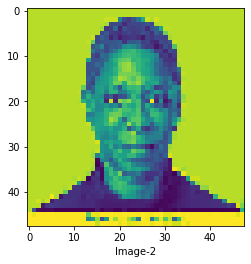

```
model1's prediction:
neutral
model2's prediction:
neutral
```

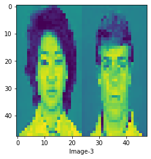

```
model1's prediction:
surprise
model2's prediction:
sad
```

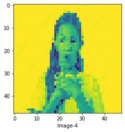

```
model1's prediction:
surprise
model2's prediction:
sad
```

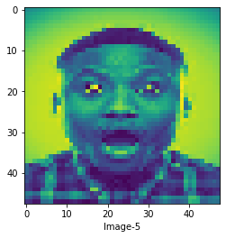

```
model1's prediction:
surprise
model2's prediction:
surprise
```

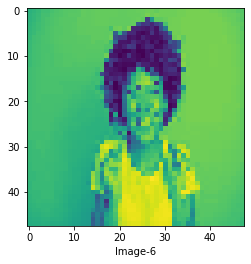

```
model1's prediction:
happy
model2's prediction:
sad
```

[figure not shown]

```
model1's prediction:
sad
model2's prediction:
neutral
```

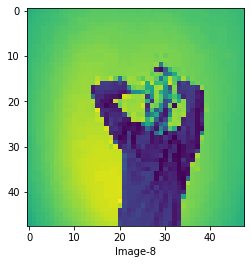

```
model1's prediction:
sad
model2's prediction:
neutral
```

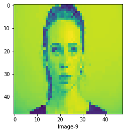

```
model1's prediction:
surprise
model2's prediction:
sad
```

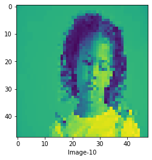

```
model1's prediction:
surprise
model2's prediction:
sad
```

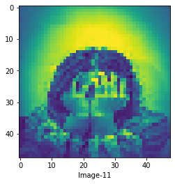

```
model1's prediction:
neutral
model2's prediction:
neutral
```

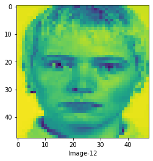

```
model1's prediction:
neutral
model2's prediction:
neutral
```

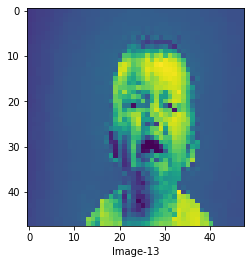

```
model1's prediction:
neutral
model2's prediction:
surprise
```

[4 more figures not shown]

```
model1's prediction:
sad
model2's prediction:
sad
```

```python
#load directory and check multiple images

img_dir = "testdata" # Enter Directory of all images
plt.figure(figsize = (1, 1))
i=0
for images in os.listdir(img_dir):
  i=i+1
  img = load_img(img_dir+"/"+images, target_size=(48, 48),color_mode='grayscale')

  x = img_to_array(img)
  x /= 255
  x = np.expand_dims(x, axis=0)

  images = np.vstack([x])
  plt.subplot(1, 1, 1)
  plt.imshow(img)
  plt.xlabel('Image-'+str(i))
  plt.show()

  classes1 = model1.predict(images)
  classes2 = model2.predict(images)

  print("model1's prediction:")
  if np.argmax(classes1)==0:
    print('happy')

  elif np.argmax(classes1)==1:
    print('neutral')

  elif np.argmax(classes1)==2:
    print('sad')

  elif np.argmax(classes1)==3:
    print('surprise')


  print("model2's prediction:")
  if np.argmax(classes2)==0:
    print('happy')

  elif np.argmax(classes2)==1:
    print('neutral')

  elif np.argmax(classes2)==2:
    print('sad')

  elif np.argmax(classes2)==3:
    print('surprise')
```

Above predictions show that both the models are not able to extract all the important features for classification.  
models are predicting accurately where expressions are very clear like image-17 but incase where person is happy, but eyes are closed or baby is crying with open mouth, models are failing to classify.

**Conclusion:** Better architecture is needed to build the model and more training data is required where similar expressions are displayed with different facial movements.

------------------------------------------------  
Lets build new model. Its exactly same model as model1 but with different filter sizes.

```python
# Initializing a Sequential Model
model3 = Sequential()
# 1st
model3.add(Conv2D(64,(5,5),padding='same',input_shape=(48,48,1),activation='relu'))
model3.add(MaxPooling2D((2,2)))
model3.add(Dropout(0.2))
#2nd
model3.add(Conv2D(32,(4,4),padding='same',activation='relu'))
model3.add(MaxPooling2D((2,2)))
model3.add(Dropout(0.2))
#3rd
model3.add(Conv2D(32,(5,5),padding='same',activation='relu'))
model3.add(MaxPooling2D((2,2)))
model3.add(Dropout(0.2))
#Flatten
model3.add(Flatten())
#Dense
model3.add(Dense(512,activation='relu'))
model3.add(Dropout(0.4))
model3.add(Dense(4,activation='softmax'))
#model summary
model3.summary()
```

```
Model: "sequential_2"
_________________________________________________________________
 Layer (type)                Output Shape              Param #
=================================================================
 conv2d_7 (Conv2D)           (None, 48, 48, 64)        1664

 max_pooling2d_6 (MaxPooling  (None, 24, 24, 64)       0
 2D)

 dropout_4 (Dropout)         (None, 24, 24, 64)        0

 conv2d_8 (Conv2D)           (None, 24, 24, 32)        32800

 max_pooling2d_7 (MaxPooling  (None, 12, 12, 32)       0
 2D)

 dropout_5 (Dropout)         (None, 12, 12, 32)        0

 conv2d_9 (Conv2D)           (None, 12, 12, 32)        25632

 max_pooling2d_8 (MaxPooling  (None, 6, 6, 32)         0
 2D)

 dropout_6 (Dropout)         (None, 6, 6, 32)          0

 flatten_2 (Flatten)         (None, 1152)              0

 dense_5 (Dense)             (None, 512)               590336

 dropout_7 (Dropout)         (None, 512)               0

 dense_6 (Dense)             (None, 4)                 2052

=================================================================
Total params: 652,484
Trainable params: 652,484
Non-trainable params: 0
_________________________________________________________________
```

```python
# Write your code to compile your model1. Use categorical crossentropy as your loss function, Adam Optimizer with 0.001 learning rate, and set your metrics to 'accuracy'.
model3.compile(optimizer=Adam(learning_rate=.001),metrics=['accuracy'],loss='categorical_crossentropy')
```

```python
# Write your code to fit your model1. Use train_set as your training data and validation_set as your validation data. Train your model for 20 epochs.

history = model3.fit(train_set,epochs=30,verbose=1,validation_data = validation_set)
```

[output not shown]

```python
model3.evaluate(test_set)
```

```
[0.7205889821052551, 0.703125]
```

**Result:** Model3 is performing better than model1 and model2. On test data its 70.31% accurate and on training and validation data its 68.42% and 69.54% respectively.

**Final Conclusion:**  
predictions were done on many images and results were clear indicative that models were not able to extract all the important features to distinguish between the expressions.

Two possible reasons could be:

1. **Model Architecture:** When we build a model then there is no said rule for filter size, number of layers, types of layers and all other parameters and hyperparameters involved. We architect, test and tune it until it produces desired result.
2. **Insufficient training data:** we need lot of data to train a model. Let say, our model never saw a image where person is happy but eyes are closed or covered or model encountered such data in very little numbers. So, when model has to predict such image then it is going to commit mistake.

Even this amount of data can give better result than what we are getting because while predicting sometimes model 1 was committing mistake and sometimes model 2. Hence, We can say that both are using some common and some completely different features for classification. So, certainly model who can extract all these features can give better result. Therefore, before flooding dataset with more data, model architecture should be redesigned.

## **Think About It:**

- Did the models have a satisfactory performance? If not, then what are the possible reasons?
- Which Color mode showed better overall performance? What are the possible reasons? Do you think having 'rgb' color mode is needed because the images are already black and white?